# PCA - Multiple Linear Regression

```r
# describe(scaled_trans_data)

# Descriptive stats after transformation
data_description <- describe(scaled_trans_data)
# Convert to data frame
as.data.frame(data_description)
```

```
                                       vars  n      mean        sd    median
better_transfusion                        1 56 0.8456872 0.1567023 0.7845847
expected_transfusion                      2 56 0.8522621 0.1906114 0.8734735
worse_transfusion                         3 56 0.8775916 0.1625020 0.9039250
better_infection                          4 56 0.8423783 0.1794803 0.8382766
expected_infection                        5 56 0.8744004 0.1817883 0.8999814
worse_infection                           6 56 0.8722419 0.1919062 0.9041454
Kt_v_1.2                                  7 56 0.8173163 0.1735678 0.7563239
Kt_v_1.7                                  8 56 0.8387822 0.1840990 0.8530291
pedriatic_Kt_v_1.2                        9 56 0.8140009 0.2580224 0.9045726
pediatric_Kt_v_1.8                       10 56 0.8122419 0.2691398 0.8661786
pediatric_nPCR                           11 56 0.7553134 0.2859853 0.8665384
better_fistula                           12 56 0.7956198 0.1949670 0.8030937
expected_fistula                         13 56 0.8509026 0.2024216 0.8717210
worse_fistula                            14 56 0.8801227 0.1663439 0.8934807
long_term_catheter                       15 56 0.8147626 0.2779052 0.8490823
hypercalcemia_calcium > 10.2Mg           16 56 0.6757604 0.1705909 0.6132644
phosphorus < 3.5Mg                       17 56 0.9049376 0.1501199 0.8638860
phosphorus (3.5 - 4.5) Mg                18 56 0.7926613 0.2399597 0.7778745
phosphorus (4.6 - 5.5) Mg                19 56 0.8486275 0.2399643 0.8810655
phosphorus (5.6 - 7) Mg                  20 56 0.8638088 0.1935517 0.8198864
phosphorus > 7Mg                         21 56 0.8477154 0.2004397 0.8460121
better_hospitalization                   22 56 0.7905419 0.1816347 0.8656693
expected_hospitalization                 23 56 0.8611638 0.1831985 0.8710916
worse_hospitalization                    24 56 0.7835396 0.2027342 0.8226738
better_hospital_readmission              25 56 0.8557249 0.1784931 0.8847755
expected_hospital_readmission            26 56 0.8580574 0.1904779 0.8775764
worse_hospital_readmission               27 56 0.8267064 0.1760511 0.8644813
better_survival                          28 56 0.8504778 0.1857527 0.8353297
expected_survival                        29 56 0.8560407 0.1883066 0.8667967
worse_survival                           30 56 0.8636800 0.1843067 0.8465591
incident_transplant_waitlist_better      31 56 0.7791225 0.1940208 0.7867828
incident_transplant_waitlist_expected    32 56 0.8174261 0.2029135 0.8263526
incident_transplant_waitlist_worse       33 56 0.7962080 0.1996704 0.8184655
prevalent_transplant_waitlist_better     34 56 0.7322455 0.1864938 0.7273970
prevalent_transplant_waitlist_expected   35 56 0.8607260 0.1896149 0.8851152
prevalent_transplant_waitlist_worse      36 56 0.8520127 0.2171307 0.9152169
Hgb_10g                                  37 56 0.7815680 0.2156102 0.7551588
Hgb_12g                                  38 56 0.9287016 0.1275945 0.8591741
                                         trimmed        mad       min      max
```

[output cut: 101 more lines]

```
worse_hospitalization                  0.02709149
better_hospital_readmission            0.02385215
expected_hospital_readmission          0.02545368
worse_hospital_readmission             0.02352582
better_survival                        0.02482224
expected_survival                      0.02516352
worse_survival                         0.02462902
incident_transplant_waitlist_better    0.02592712
incident_transplant_waitlist_expected  0.02711545
incident_transplant_waitlist_worse     0.02668208
prevalent_transplant_waitlist_better   0.02492128
prevalent_transplant_waitlist_expected 0.02533835
prevalent_transplant_waitlist_worse    0.02901530
Hgb_10g                                0.02881212
Hgb_12g                                0.01705053
```

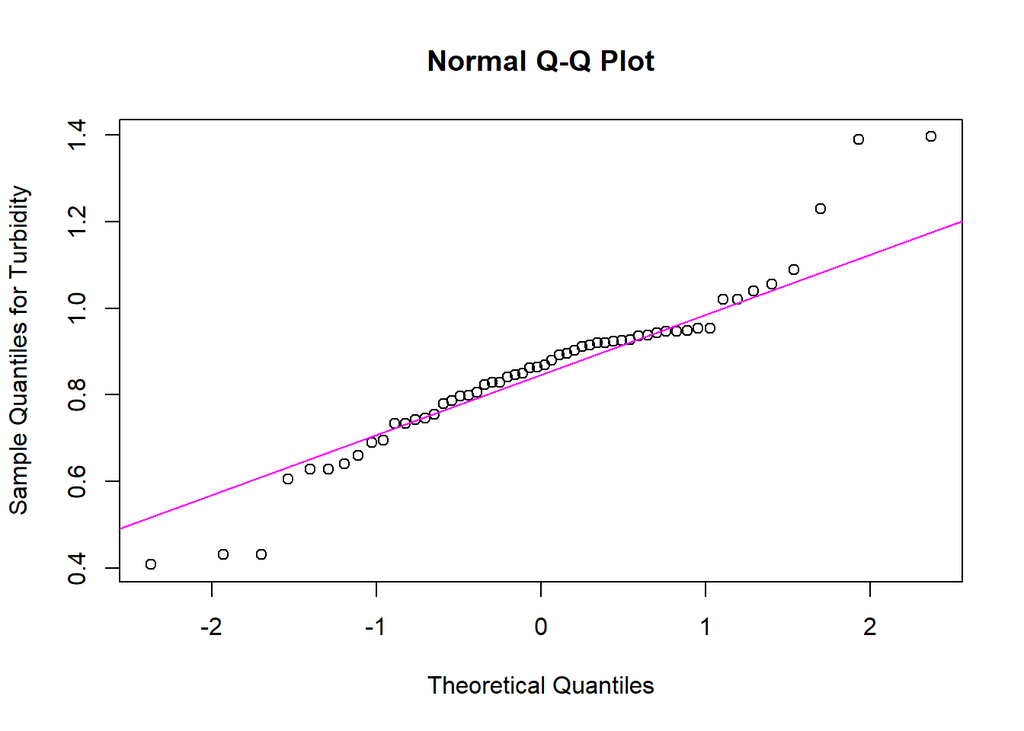

```r
qqnorm(scaled_trans_data$expected_survival,
       ylab="Sample Quantiles for Turbidity")
qqline(scaled_trans_data$expected_survival, col="magenta")
```

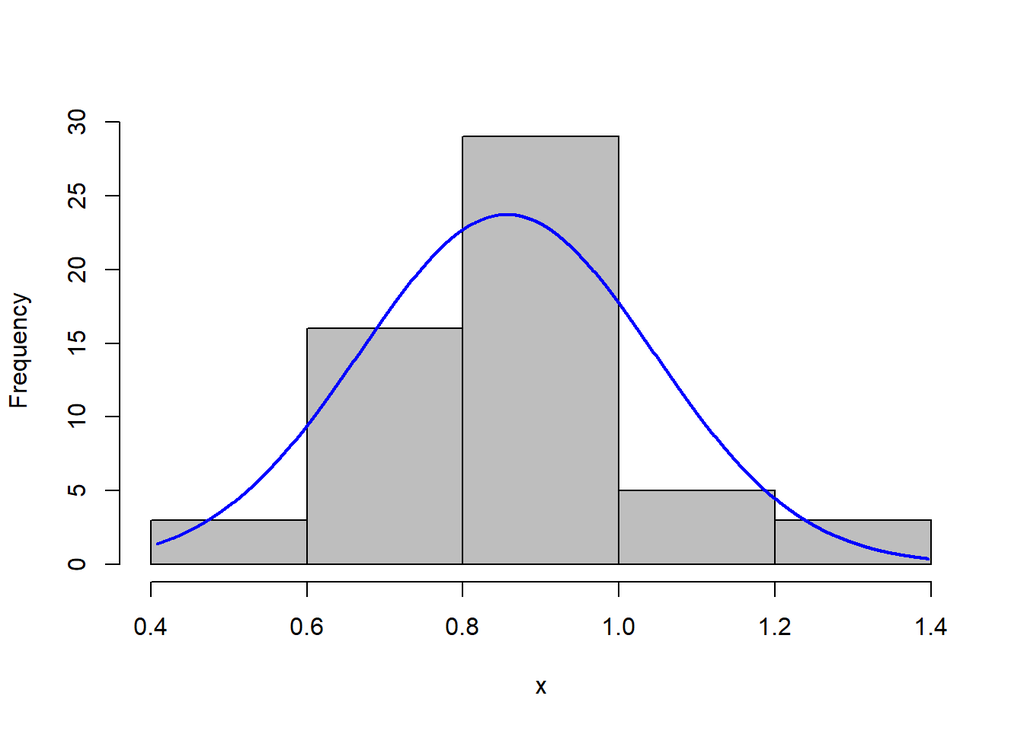

```r
plotNormalHistogram(scaled_trans_data$expected_survival)
```

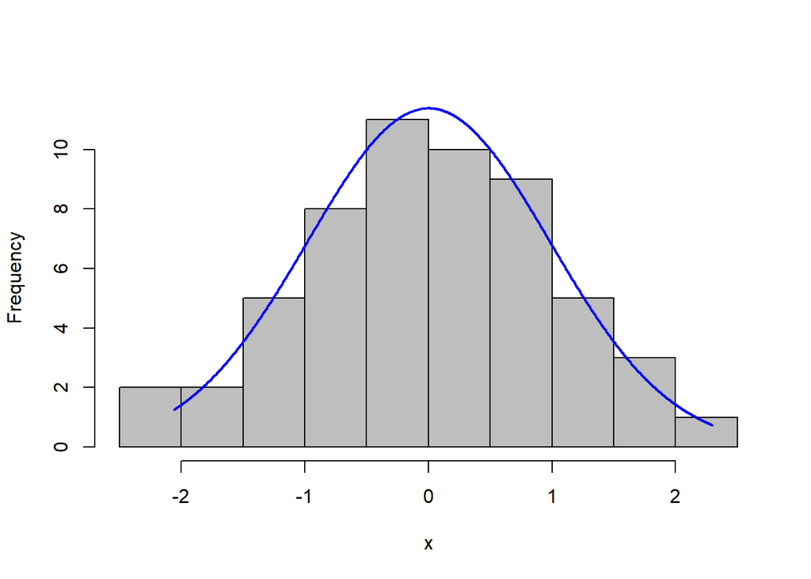

```r
# Normal Scores Transformation
standard_df$expected_survival_N_scores <- blom(standard_df$expected_survival)

plotNormalHistogram(standard_df$expected_survival_N_scores)
```

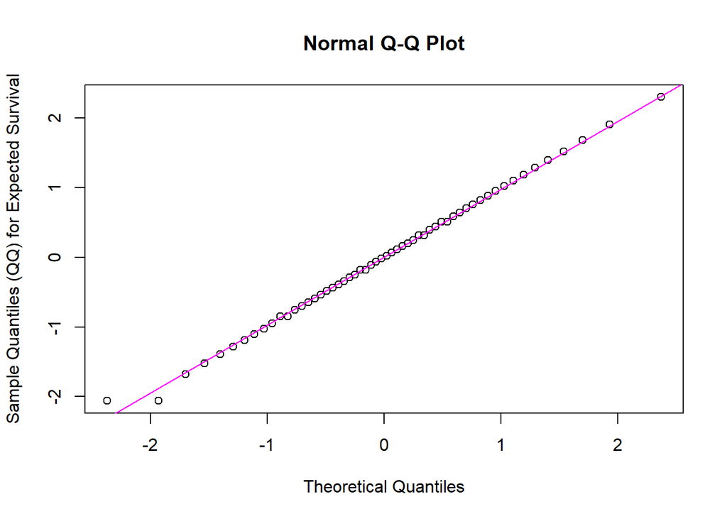

```r
# QQ plot
qqnorm(standard_df$expected_survival_N_scores,
       ylab="Sample Quantiles (QQ) for Expected Survival")
qqline(standard_df$expected_survival_N_scores, col="magenta")
```

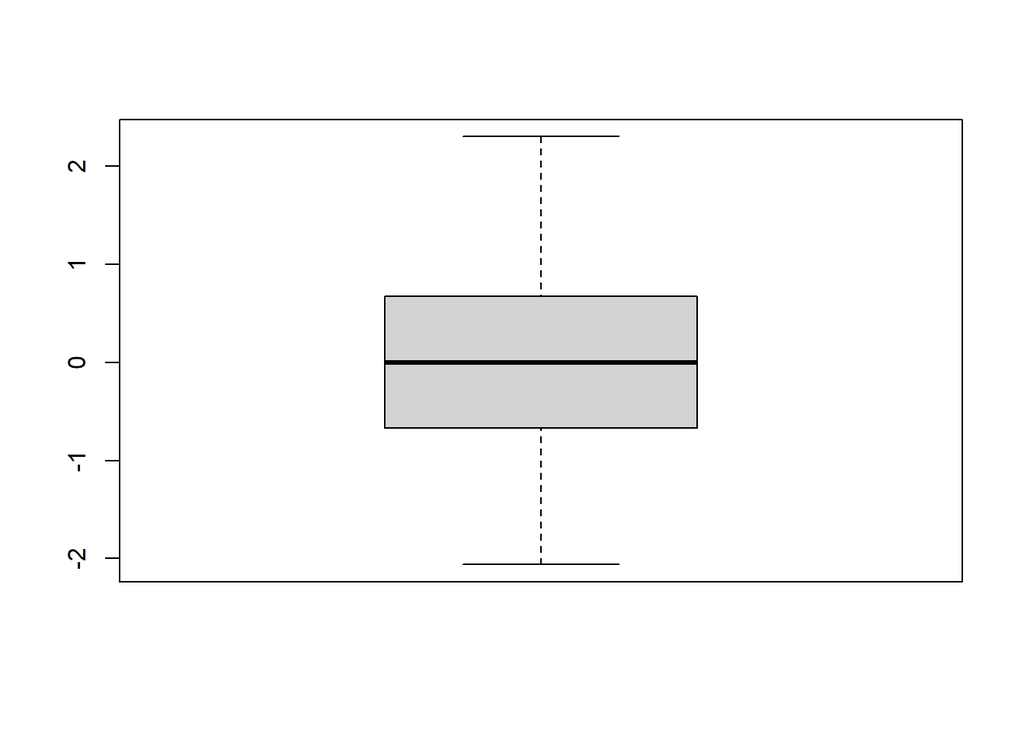

```r
boxplot(standard_df$expected_survival_N_scores)
```

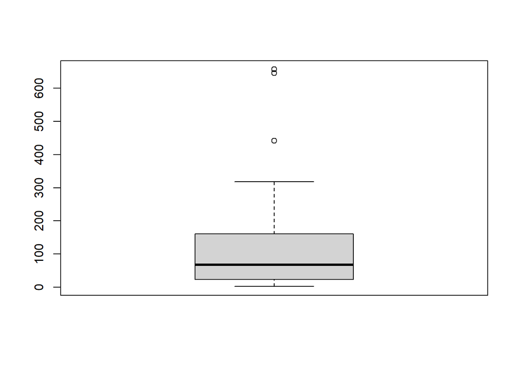

```r
boxplot(train_data$expected_survival)
```

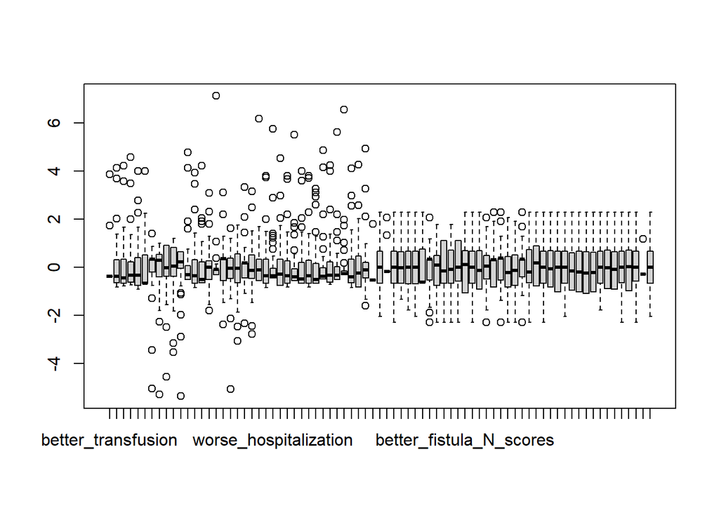

```r
# Create a new data frame to store the transformed variables
standard_scores_df <- standard_df

# Loop through each column and apply the Normal Scores transformation
for (col in colnames(standard_df)) {
  transformed_col_name <- paste0(col, "_N_scores")  # Create a new column name for the transformed variable
  standard_scores_df[[transformed_col_name]] <- blom(standard_df[[col]])
}

boxplot(standard_scores_df)
```

## Correlations

- There are high correlated features.
- Multicollinearity is present in the data set

```r
# Calculate correlations and round to 2 digits
corr_matrix <- cor(scaled_trans_data)
corr_matrix <- round(corr_matrix, digits = 2)

# Print names of highly correlated features; threshold > 0.30
high <- findCorrelation(corr_matrix, cutoff = 0.30, names = TRUE)
as.data.frame(high)
```

```
                                     high
1                       expected_survival
2                expected_hospitalization
3           expected_hospital_readmission
4                        expected_fistula
5                    expected_transfusion
6  prevalent_transplant_waitlist_expected
7                      expected_infection
8                        better_infection
9   incident_transplant_waitlist_expected
10             worse_hospital_readmission
11                         worse_survival
12                         better_fistula
13    incident_transplant_waitlist_better
14     incident_transplant_waitlist_worse
15                  worse_hospitalization
16                          worse_fistula
17                 better_hospitalization
18                phosphorus (5.6 - 7) Mg
19                                Hgb_10g
20                     better_transfusion
21                        better_survival
22                               Kt_v_1.2
23              phosphorus (3.5 - 4.5) Mg
24    prevalent_transplant_waitlist_worse
25                       phosphorus > 7Mg
26         hypercalcemia_calcium > 10.2Mg
27              phosphorus (4.6 - 5.5) Mg
28                         pediatric_nPCR
```

```r
# Calculate correlation table
corr_table<- function(df){
  # Correlation
  corr <- cor(df)
  # Prepare to drop duplicates and correlations of 1
  corr[lower.tri(corr,diag=TRUE)] <- NA
  # Drop perfect correlations
  corr[corr == 1] <- NA

  # Turn into a 3-column table
  corr <- as.data.frame(as.table(corr))
  # Remove the NA values from above
  corr <- na.omit(corr)

  # Select significant values
  sig=0.5
  corr <- subset(corr, abs(Freq) > sig)
  # Sort by highest correlation
  corr <- corr[order(-abs(corr$Freq)),]

}
correlation_table <- corr_table(scaled_trans_data)
correlation_table
```

```
                                      Var1
1087              expected_hospitalization
973               expected_hospitalization
1090         expected_hospital_readmission
1321                     expected_survival
1315              expected_hospitalization
1318         expected_hospital_readmission
849                       expected_fistula
952                   expected_transfusion
1077                      expected_fistula
963                       expected_fistula
838                   expected_transfusion
1305                      expected_fistula
1066                  expected_transfusion
1069                    expected_infection
```

[output cut: 167 more lines]

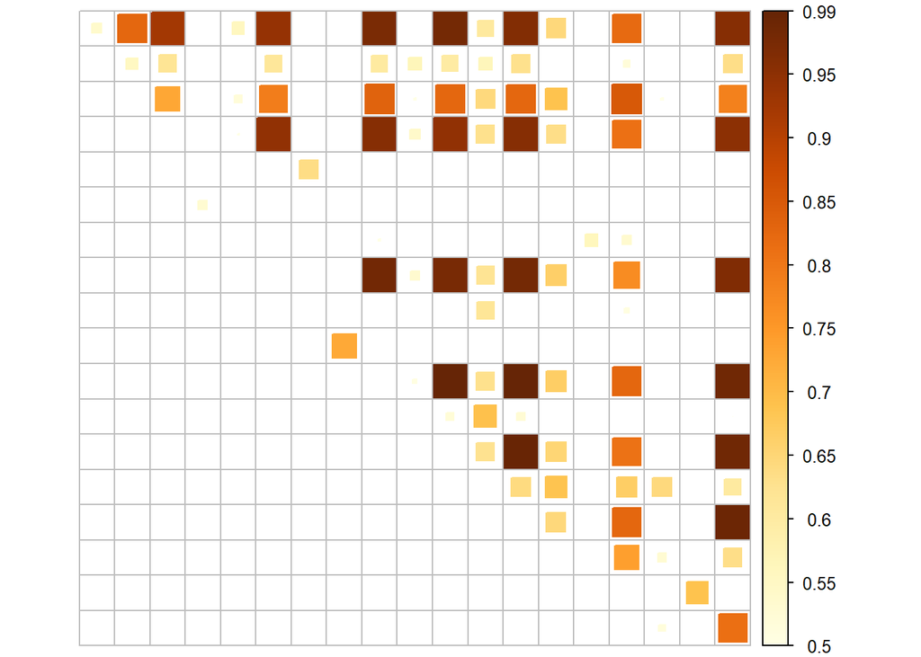

```r
# Transform correlation table back into matrix form
  mtx_corr <- reshape2::acast(correlation_table,
                              Var1~Var2, value.var="Freq")

# Plot significant correlations
  corrplot::corrplot(mtx_corr, is.corr=FALSE,
                     tl.col="black", na.label=" ",
                     tl.cex = 0.55,
                     method = "square",
                     tl.pos = "n"
                     )
```

# 03 - Full Model Regression

## Target Feature

```r
# Find the index position of the target feature
target_name <- "expected_survival"
target_index <- grep(target_name,
                     colnames(scaled_trans_data))
```

```r
set.seed(my_seed)

# Fit a multiple linear regression model
full_model <- lm(expected_survival ~ ., data = scaled_trans_data)

# Print a summary of the regression model
summary(full_model)
```

```
Call:
lm(formula = expected_survival ~ ., data = scaled_trans_data)

Residuals:
       Min         1Q     Median         3Q        Max
-0.0224136 -0.0061891 -0.0000363  0.0057598  0.0305803

Coefficients:
                                        Estimate Std. Error t value Pr(>|t|)
(Intercept)                            -0.082288   0.069286  -1.188   0.2504
better_transfusion                      0.047760   0.030489   1.566   0.1346
expected_transfusion                   -0.157893   0.111610  -1.415   0.1742
worse_transfusion                       0.005251   0.030614   0.172   0.8657
better_infection                        0.052648   0.057562   0.915   0.3725
expected_infection                      0.082551   0.084471   0.977   0.3414
worse_infection                         0.002859   0.028519   0.100   0.9212
Kt_v_1.2                               -0.017362   0.036268  -0.479   0.6379
Kt_v_1.7                                0.011564   0.020860   0.554   0.5862
pedriatic_Kt_v_1.2                      0.003491   0.020122   0.173   0.8642
pediatric_Kt_v_1.8                     -0.001218   0.013033  -0.093   0.9266
pediatric_nPCR                         -0.001760   0.015785  -0.112   0.9125
better_fistula                          0.046459   0.030038   1.547   0.1393
expected_fistula                        0.065317   0.143911   0.454   0.6553
worse_fistula                           0.029963   0.039856   0.752   0.4619
long_term_catheter                     -0.020000   0.015828  -1.264   0.2225
`hypercalcemia_calcium > 10.2Mg`        0.029225   0.024954   1.171   0.2568
`phosphorus < 3.5Mg`                    0.025205   0.024649   1.023   0.3201
`phosphorus (3.5 - 4.5) Mg`             0.009658   0.024774   0.390   0.7012
`phosphorus (4.6 - 5.5) Mg`             0.013235   0.023032   0.575   0.5726
`phosphorus (5.6 - 7) Mg`              -0.015456   0.022318  -0.693   0.4974
`phosphorus > 7Mg`                     -0.027489   0.030844  -0.891   0.3846
better_hospitalization                 -0.008455   0.025120  -0.337   0.7403
expected_hospitalization                0.717558   0.342735   2.094   0.0507 .
worse_hospitalization                  -0.037646   0.032345  -1.164   0.2597
better_hospital_readmission            -0.038306   0.026787  -1.430   0.1698
expected_hospital_readmission          -0.025015   0.235282  -0.106   0.9165
worse_hospital_readmission              0.057012   0.059195   0.963   0.3482
better_survival                        -0.024179   0.024047  -1.005   0.3280
worse_survival                         -0.091463   0.031994  -2.859   0.0104 *
incident_transplant_waitlist_better    -0.006076   0.033896  -0.179   0.8597
incident_transplant_waitlist_expected   0.007830   0.044758   0.175   0.8631
incident_transplant_waitlist_worse      0.021281   0.031725   0.671   0.5109
prevalent_transplant_waitlist_better   -0.036254   0.029684  -1.221   0.2377
prevalent_transplant_waitlist_expected  0.321700   0.155359   2.071   0.0530 .
prevalent_transplant_waitlist_worse     0.009877   0.021187   0.466   0.6467
Hgb_10g                                -0.005902   0.023480  -0.251   0.8044
Hgb_12g                                 0.040467   0.035003   1.156   0.2628
---
Signif. codes:  0 '***' 0.001 '**' 0.01 '*' 0.05 '.' 0.1 ' ' 1

Residual standard error: 0.01743 on 18 degrees of freedom
Multiple R-squared:  0.9972,    Adjusted R-squared:  0.9914
F-statistic: 172.9 on 37 and 18 DF,  p-value: < 2.2e-16
```

# 04 - SVD - Singular Value Decomposition

- Note: The Spectral Decomposition approach is used with the princomp() function.

```r
# Apply PCA using prcomp()
data_pca <- prcomp(scaled_trans_data, center = TRUE, scale. = TRUE)
summary(data_pca)
```

```
Importance of components:
                          PC1    PC2     PC3     PC4     PC5    PC6     PC7
Standard deviation     3.4516 2.0349 1.66299 1.48189 1.31194 1.2945 1.20873
Proportion of Variance 0.3135 0.1090 0.07278 0.05779 0.04529 0.0441 0.03845
Cumulative Proportion  0.3135 0.4225 0.49526 0.55305 0.59834 0.6424 0.68089
                           PC8     PC9    PC10    PC11    PC12    PC13    PC14
Standard deviation     1.15123 1.08996 0.99689 0.97951 0.92166 0.90432 0.84087
Proportion of Variance 0.03488 0.03126 0.02615 0.02525 0.02235 0.02152 0.01861
Cumulative Proportion  0.71577 0.74703 0.77318 0.79843 0.82079 0.84231 0.86091
                          PC15    PC16    PC17    PC18    PC19    PC20   PC21
Standard deviation     0.81817 0.79743 0.73074 0.70635 0.65347 0.60741 0.5977
Proportion of Variance 0.01762 0.01673 0.01405 0.01313 0.01124 0.00971 0.0094
Cumulative Proportion  0.87853 0.89526 0.90932 0.92245 0.93368 0.94339 0.9528
                         PC22    PC23    PC24    PC25    PC26    PC27    PC28
Standard deviation     0.5479 0.51226 0.48628 0.44946 0.41037 0.39372 0.37400
Proportion of Variance 0.0079 0.00691 0.00622 0.00532 0.00443 0.00408 0.00368
Cumulative Proportion  0.9607 0.96760 0.97382 0.97914 0.98357 0.98765 0.99133
                          PC29    PC30    PC31    PC32    PC33    PC34    PC35
Standard deviation     0.30557 0.27846 0.26433 0.18647 0.14852 0.13481 0.08434
Proportion of Variance 0.00246 0.00204 0.00184 0.00092 0.00058 0.00048 0.00019
Cumulative Proportion  0.99379 0.99583 0.99767 0.99858 0.99916 0.99964 0.99983
                          PC36    PC37    PC38
Standard deviation     0.05845 0.04837 0.02879
Proportion of Variance 0.00009 0.00006 0.00002
Cumulative Proportion  0.99992 0.99998 1.00000
```

## PCA - Elements

- The values in **`data_pca$x`** are the coordinates of each observation in the new principal component space. These coordinates are the scores for each observation along each principal component.
- The eigenvectors of the covariance or correlation matrix of the data represent the directions of maximum variance or information in the dataset.

```r
# Principal Component scores vector
pc_scores <- data_pca$x

# Std Deviation of Components
component_sdev <- data_pca$sdev

# Eigenvector, or Loadings
eigenvector <- data_pca$rotation

# Mean of variables
component_mean <- data_pca$center

# Scaling factor of Variables
component_scale <- data_pca$scale
```

## Loading of First Two Components

- The loading are the weights assigned to each variable for that particular principal component.

```r
# Access the loadings for the first two principal components
loadings_first_two_components <- eigenvector[, 1:2]

# Print the loadings for the first two principal components
print("Loadings for the first two principal components:")
```

```
[1] "Loadings for the first two principal components:"
```

```r
print(loadings_first_two_components)
```

```
                                                PC1          PC2
better_transfusion                      0.072136225 -0.240317659
expected_transfusion                    0.272474561 -0.001579032
worse_transfusion                       0.190143080  0.061865021
better_infection                        0.253730464  0.016296786
expected_infection                      0.270024671  0.035490226
worse_infection                         0.067323529  0.009781312
Kt_v_1.2                                0.053763512 -0.271903345
Kt_v_1.7                               -0.001854920 -0.181364256
pedriatic_Kt_v_1.2                     -0.063831924 -0.027836192
pediatric_Kt_v_1.8                     -0.059430218  0.123084357
pediatric_nPCR                         -0.044660666 -0.070563310
better_fistula                          0.167792386 -0.096735164
expected_fistula                        0.272889343  0.006353478
worse_fistula                           0.143920142  0.147608428
long_term_catheter                      0.018974999 -0.135782075
hypercalcemia_calcium > 10.2Mg         -0.037774392 -0.214223752
phosphorus < 3.5Mg                      0.041491491 -0.304560269
phosphorus (3.5 - 4.5) Mg               0.006746877 -0.375409931
phosphorus (4.6 - 5.5) Mg               0.033825693 -0.194660834
phosphorus (5.6 - 7) Mg                 0.071769563 -0.276929285
phosphorus > 7Mg                        0.018650925 -0.352288860
better_hospitalization                  0.093624902  0.060821019
expected_hospitalization                0.279855910  0.014614576
worse_hospitalization                   0.166143556  0.086377654
better_hospital_readmission             0.129272286  0.074535755
expected_hospital_readmission           0.277471234  0.014111829
worse_hospital_readmission              0.218679573  0.055182831
better_survival                         0.095426316 -0.096163927
expected_survival                       0.279674052  0.018780246
worse_survival                          0.212756114  0.079158187
incident_transplant_waitlist_better     0.142235298 -0.159612832
incident_transplant_waitlist_expected   0.254058002  0.038671783
incident_transplant_waitlist_worse      0.156592694  0.043790391
prevalent_transplant_waitlist_better    0.123296847 -0.112382937
prevalent_transplant_waitlist_expected  0.272263000  0.043835387
prevalent_transplant_waitlist_worse     0.063936511  0.197373520
Hgb_10g                                 0.054142110 -0.331834448
Hgb_12g                                 0.045834627 -0.112351415
```

## PCA - Cumulative Variance

```r
# Proportion of variance explained by each PC
variance_explained <- component_sdev^2 / sum(component_sdev^2)

# Cumulative proportion of variance explained
cumulative_variance_explained <- cumsum(variance_explained)
cumulative_variance_explained
```

```
 [1] 0.3135067 0.4224806 0.4952574 0.5530466 0.5983411 0.6424425 0.6808908
 [8] 0.7157681 0.7470318 0.7731839 0.7984324 0.8207867 0.8423077 0.8609147
[15] 0.8785304 0.8952645 0.9093165 0.9224463 0.9336838 0.9433929 0.9527938
[22] 0.9606928 0.9675983 0.9738213 0.9791374 0.9835690 0.9876484 0.9913294
[29] 0.9937866 0.9958271 0.9976658 0.9985808 0.9991613 0.9996396 0.9998267
[36] 0.9999166 0.9999782 1.0000000
```

## PCA - Number of Principal Components

```r
# Retain components that explain a percentage of the variance
num_components <- which(cumulative_variance_explained >= 0.86)[1]

# Select the desired number of principal components
selected_pcs <- pc_scores[, 1:num_components]
selected_pcs
```

```
           PC1         PC2          PC3         PC4         PC5           PC6
1   1.42389634 -0.54021985 -0.764084348 -0.56425934 -0.81591439 -1.3338083542
2  -3.66527718 -0.13095254  0.177305226  0.71559486 -3.00106905 -0.4487667513
3  -1.44151811 -0.14117499  0.139721866 -0.13670614 -1.22821407  0.7347066176
4   1.51427830  3.42030201  0.356259707  1.16298424 -1.39917892  1.6800841583
5  -5.82531582  0.45260881  0.847625352  0.23729682  3.19646185  0.8113274780
6  11.25234555 -0.73715861  7.725776366  2.56050810  1.43530038 -0.6892120573
7  -1.91958590  0.31679309 -0.512637312  1.32869213  0.24752229 -0.2192538655
8  -0.34648877 -0.01396032  0.338760506  1.45391057 -0.48363188 -1.4039306456
9   0.95445230  0.13325071  0.492240663  0.10229649 -0.33554955 -1.4083051777
10  0.11714938  0.14399843 -0.698584127 -1.26155196  1.13488699  1.2665318860
11  7.94329704  3.54257611 -4.123654353 -0.14768405  2.92420074 -1.3544061039
12  4.17381958  3.72620507 -1.873494818 -0.77893321  0.14827361  0.4682427080
13  2.06539754 -4.60823112 -0.150951731 -1.34062769 -0.64736100 -1.5340521748
14  0.35018942 -1.32854011  1.109385643  0.86954064 -0.06344891 -0.7556275577
```

[output cut: 156 more lines]

# 05 - Visualization

## Scree Plot - Cumulative Variance Explained

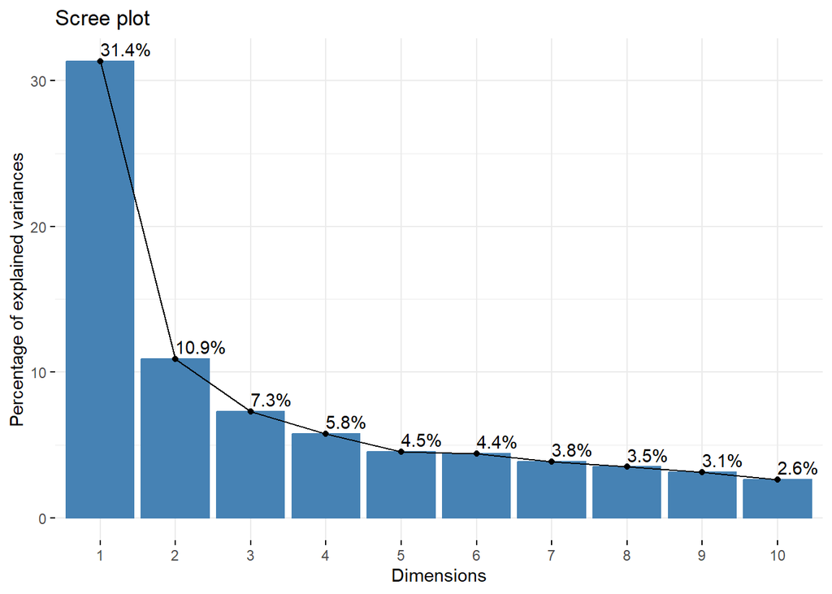

```r
fviz_eig(data_pca, addlabels = TRUE)
```

## Biplot

The correlation between a variable and a principal component (PC) is used as the coordinates of the variable on the PC. The representation of variables differs from the plot of the observations: The observations are represented by their projections, but the variables are represented by their correlations (Abdi and Williams 2010).

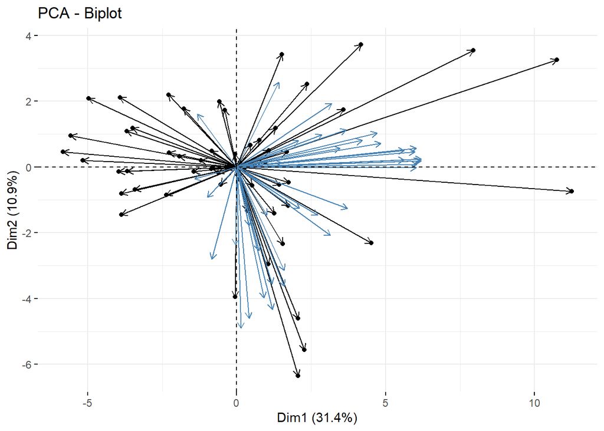

```r
fviz_pca_biplot(data_pca,
                geom = c("point", "arrow"),
                geom.var = "arrow")
```

## Correlation Circle

The plot below is also known as variable correlation plots. It shows the relationships between all variables. It can be interpreted as follow:

- Positively correlated variables are grouped together.
- Negatively correlated variables are positioned on opposite sides of the plot origin (opposed quadrants).
- The distance between variables and the origin measures the quality of the variables on the factor map. Variables that are away from the origin are well represented on the factor map.

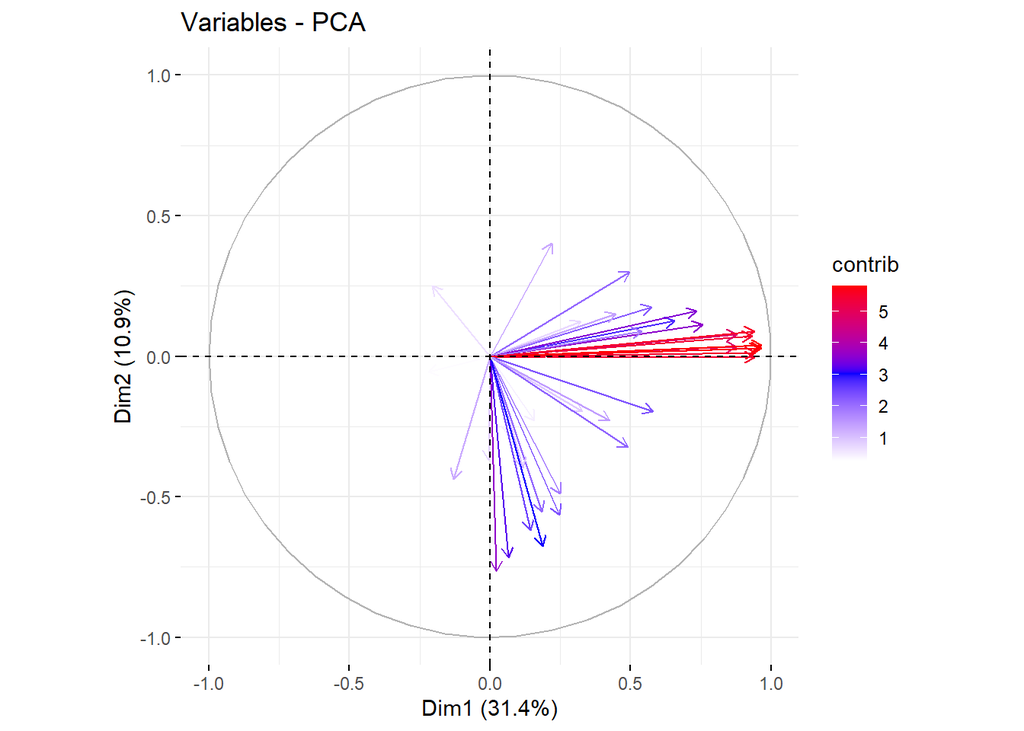

```r
# Control variable colors using their contributions
fviz_pca_var(data_pca, col.var = "contrib",
   gradient.cols = c("white", "blue", "red"),
   geom.var = "arrow",
   ggtheme = theme_minimal())
```